# W3cubDocs

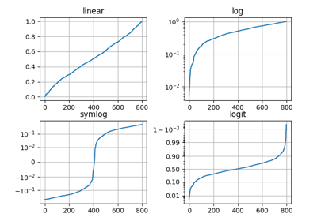

[Pyplot Scales](https://matplotlib.org/3.1.1/gallery/pyplots/pyplot_scales.html#sphx-glr-gallery-pyplots-pyplot-scales-py)

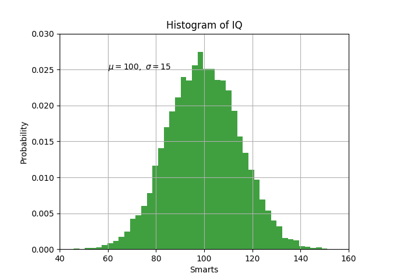

[Pyplot Text](https://matplotlib.org/3.1.1/gallery/pyplots/pyplot_text.html#sphx-glr-gallery-pyplots-pyplot-text-py)

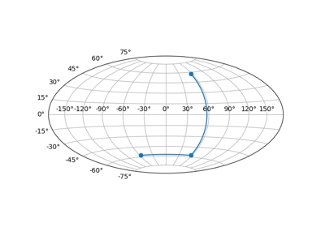

[Custom projection](https://matplotlib.org/3.1.1/gallery/misc/custom_projection.html#sphx-glr-gallery-misc-custom-projection-py)

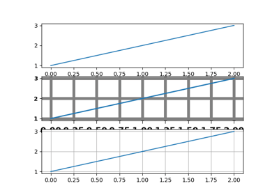

[Customize Rc](https://matplotlib.org/3.1.1/gallery/misc/customize_rc.html#sphx-glr-gallery-misc-customize-rc-py)

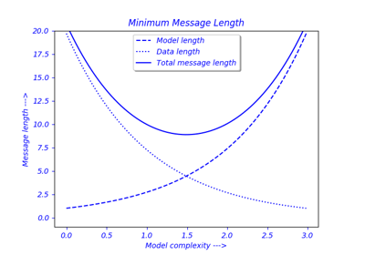

[Findobj Demo](https://matplotlib.org/3.1.1/gallery/misc/findobj_demo.html#sphx-glr-gallery-misc-findobj-demo-py)

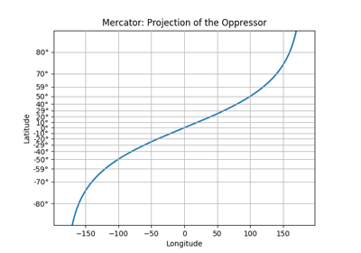

[Custom scale](https://matplotlib.org/3.1.1/gallery/scales/custom_scale.html#sphx-glr-gallery-scales-custom-scale-py)

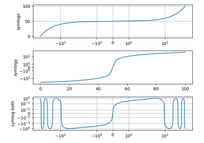

[Symlog Demo](https://matplotlib.org/3.1.1/gallery/scales/symlog_demo.html#sphx-glr-gallery-scales-symlog-demo-py)

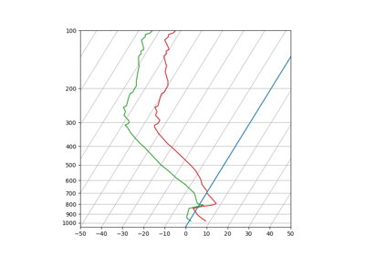

[SkewT-logP diagram: using transforms and custom projections](https://matplotlib.org/3.1.1/gallery/specialty_plots/skewt.html#sphx-glr-gallery-specialty-plots-skewt-py)

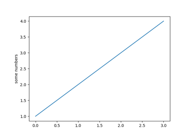

[Pyplot tutorial](https://matplotlib.org/3.1.1/tutorials/introductory/pyplot.html#sphx-glr-tutorials-introductory-pyplot-py)